# **Project : AI-Driven Temperature Analysis for Better Educational Environments in Tanzania**

## **Project Goal :** Develop a predictive model using AI, satellite imagery / remote sensing data, and classroom characteristics (e.g., ceiling boards). that can estimate indoor classroom temperatures.

## **0. Import Libraries**

```python
#=================================================================
# For data processing, plotting, and miscellaneous
#=================================================================
import numpy as np
import pandas as pd
import matplotlib.pyplot as plt
import matplotlib as mpl
#plt.style.use('fivethirtyeight')
%matplotlib inline
import seaborn as sns
import warnings
warnings.filterwarnings("ignore", category=DeprecationWarning)
import math
import calendar
from datetime import datetime
import datetime
#===================================================================
# Import Keras models, layers, optimizers
#===================================================================
import tensorflow as tf
tf.random.set_seed(3)
import keras
from keras import datasets, models
from keras.models import Sequential
from keras.layers import LSTM, GRU, Dense, ReLU, Dropout
from keras import regularizers
from keras import optimizers
from keras.optimizers import SGD, Adam, RMSprop
from keras.callbacks import EarlyStopping
from keras.preprocessing.sequence import TimeseriesGenerator
from keras.layers import GaussianNoise
from keras.layers import BatchNormalization
from keras.models import load_model
#====================================================================
# From sklearn import required classes
#====================================================================
from sklearn import preprocessing
from sklearn import metrics
from sklearn.preprocessing import MinMaxScaler
from sklearn.model_selection import train_test_split
from sklearn.metrics import r2_score
from sklearn.metrics import mean_absolute_error, mean_squared_error, root_mean_squared_error
from sklearn.preprocessing import FunctionTransformer
from sklearn.compose import ColumnTransformer
```

## **1. Import the Dataset**

**Dataset Source :**

https://github.com/OmdenaAI/OpenDevEd/blob/task_3_data_processing_analysis/abhishek_dutta/outputs/combined_dataset_openmeteo_ndvi_ndwi_gt.csv

```python
df_initial = pd.read_csv('combined_dataset_openmeteo_ndvi_ndwi_gt.csv')

print(df_initial.columns)
```

```
Index(['Date/Time EAT', 'school_name', 'school_latitude', 'school_longitude',
       'weather_station_latitude', 'weather_station_longitude',
       'temperature_2m', 'relative_humidity_2m', 'direct_normal_irradiance',
       'shortwave_radiation', 'wind_speed_10m', 'precipitation', 'cloud_cover',
       'elevation', 'Avg_indoor_temp(hourly)', 'NDVI(monthly)',
       'NDWI(monthly)'],
      dtype='object')
```

```python
df_initial.head()
```

|  | Date/Time EAT | school_name | school_latitude | school_longitude | weather_station_latitude | weather_station_longitude | temperature_2m | relative_humidity_2m | direct_normal_irradiance | shortwave_radiation | wind_speed_10m | precipitation | cloud_cover | elevation | Avg_indoor_temp(hourly) | NDVI(monthly) | NDWI(monthly) |
| --- | --- | --- | --- | --- | --- | --- | --- | --- | --- | --- | --- | --- | --- | --- | --- | --- | --- |
| 0 | 2023-12-10 14:00:00 | Kijichi Secondary School | -6.876 | 39.298 | -6.85413 | 39.275486 | 28.3385 | 78.260270 | 642.35930 | 838.0 | 12.682018 | 0.0 | 34.500000 | 0.0 | 30.650000 | 0.247 | 0.375 |
| 1 | 2023-12-10 14:00:00 | Kijichi Primary School | -6.886 | 39.280 | -6.85413 | 39.275486 | 28.0850 | 78.224110 | 642.35930 | 838.0 | 12.682018 | 0.0 | 34.500000 | 39.0 | 30.650000 | 0.166 | 0.126 |
| 2 | 2023-12-10 15:00:00 | Kijichi Primary School | -6.886 | 39.280 | -6.85413 | 39.275486 | 28.0350 | 78.452390 | 816.48780 | 787.0 | 12.783802 | 0.0 | 28.799997 | 39.0 | 31.116667 | 0.166 | 0.126 |
| 3 | 2023-12-10 15:00:00 | Kijichi Secondary School | -6.876 | 39.298 | -6.85413 | 39.275486 | 28.2885 | 78.488235 | 816.48780 | 787.0 | 12.783802 | 0.0 | 28.799997 | 0.0 | 31.116667 | 0.247 | 0.375 |
| 4 | 2023-12-10 16:00:00 | Kijichi Secondary School | -6.876 | 39.298 | -6.85413 | 39.275486 | 26.3385 | 86.160340 | 86.23866 | 283.0 | 11.090103 | 0.8 | 53.700000 | 0.0 | 30.691666 | 0.247 | 0.375 |

```python
df_initial = df_initial[df_initial['school_name']=="Kijichi Primary School"]
```

```python
df_initial = df_initial.reset_index(drop=True)
```

```python
df_initial
```

|  | Date/Time EAT | school_name | school_latitude | school_longitude | weather_station_latitude | weather_station_longitude | temperature_2m | relative_humidity_2m | direct_normal_irradiance | shortwave_radiation | wind_speed_10m | precipitation | cloud_cover | elevation | Avg_indoor_temp(hourly) | NDVI(monthly) | NDWI(monthly) |
| --- | --- | --- | --- | --- | --- | --- | --- | --- | --- | --- | --- | --- | --- | --- | --- | --- | --- |
| 0 | 2023-12-10 14:00:00 | Kijichi Primary School | -6.886 | 39.28 | -6.85413 | 39.275486 | 28.085000 | 78.224110 | 642.35930 | 838.0 | 12.682018 | 0.0 | 34.500000 | 39.0 | 30.650000 | 0.166 | 0.126 |
| 1 | 2023-12-10 15:00:00 | Kijichi Primary School | -6.886 | 39.28 | -6.85413 | 39.275486 | 28.035000 | 78.452390 | 816.48780 | 787.0 | 12.783802 | 0.0 | 28.799997 | 39.0 | 31.116667 | 0.166 | 0.126 |
| 2 | 2023-12-10 16:00:00 | Kijichi Primary School | -6.886 | 39.28 | -6.85413 | 39.275486 | 26.085000 | 86.136040 | 86.23866 | 283.0 | 11.090103 | 0.8 | 53.700000 | 39.0 | 30.691666 | 0.166 | 0.126 |
| 3 | 2023-12-10 17:00:00 | Kijichi Primary School | -6.886 | 39.28 | -6.85413 | 39.275486 | 26.685000 | 83.390450 | 471.46994 | 341.0 | 8.557102 | 0.1 | 44.700005 | 39.0 | 30.258333 | 0.166 | 0.126 |
| 4 | 2023-12-10 18:00:00 | Kijichi Primary School | -6.886 | 39.28 | -6.85413 | 39.275486 | 26.234999 | 85.118835 | 330.97580 | 131.0 | 5.091168 | 0.0 | 82.800000 | 39.0 | 29.416666 | 0.166 | 0.126 |
| ... | ... | ... | ... | ... | ... | ... | ... | ... | ... | ... | ... | ... | ... | ... | ... | ... | ... |
| 2109 | 2024-03-07 11:00:00 | Kijichi Primary School | -6.886 | 39.28 | -6.85413 | 39.275486 | 31.335000 | 64.290650 | 808.10205 | 817.0 | 7.421590 | 0.0 | 20.099998 | 39.0 | 32.658333 | 0.151 | 0.160 |
| 2110 | 2024-03-07 12:00:00 | Kijichi Primary School | -6.886 | 39.28 | -6.85413 | 39.275486 | 31.984999 | 60.852050 | 768.71220 | 889.0 | 9.064569 | 0.0 | 24.300000 | 39.0 | 33.024998 | 0.151 | 0.160 |
| 2111 | 2024-03-07 13:00:00 | Kijichi Primary School | -6.886 | 39.28 | -6.85413 | 39.275486 | 32.335003 | 58.059460 | 790.75146 | 960.0 | 10.086427 | 0.1 | 20.700000 | 39.0 | 33.399998 | 0.151 | 0.160 |
| 2112 | 2024-03-07 14:00:00 | Kijichi Primary School | -6.886 | 39.28 | -6.85413 | 39.275486 | 32.685000 | 56.409695 | 779.67530 | 924.0 | 11.252519 | 0.0 | 15.600000 | 39.0 | 33.550000 | 0.151 | 0.160 |
| 2113 | 2024-03-07 15:00:00 | Kijichi Primary School | -6.886 | 39.28 | -6.85413 | 39.275486 | 32.535000 | 54.687073 | 781.75665 | 831.0 | 12.605142 | 0.0 | 12.600000 | 39.0 | 34.350000 | 0.151 | 0.160 |

2114 rows × 17 columns

```python
df_initial.to_csv("sorted_data.csv")
```

```python
req_cols = ['Date/Time EAT','Avg_indoor_temp(hourly)', 'school_latitude', 'school_longitude',
            'temperature_2m', 'relative_humidity_2m', 'direct_normal_irradiance',
            'shortwave_radiation', 'wind_speed_10m', 'precipitation', 'cloud_cover',
            'elevation', 'NDVI(monthly)',
            'NDWI(monthly)']
```

```python
df_initial = df_initial[req_cols]
```

```python
df_initial.info()
```

```
<class 'pandas.core.frame.DataFrame'>
RangeIndex: 2114 entries, 0 to 2113
Data columns (total 14 columns):
 #   Column                    Non-Null Count  Dtype
---  ------                    --------------  -----
 0   Date/Time EAT             2114 non-null   object
 1   Avg_indoor_temp(hourly)   2114 non-null   float64
 2   school_latitude           2114 non-null   float64
 3   school_longitude          2114 non-null   float64
 4   temperature_2m            2114 non-null   float64
 5   relative_humidity_2m      2114 non-null   float64
 6   direct_normal_irradiance  2114 non-null   float64
 7   shortwave_radiation       2114 non-null   float64
 8   wind_speed_10m            2114 non-null   float64
 9   precipitation             2114 non-null   float64
 10  cloud_cover               2114 non-null   float64
 11  elevation                 2114 non-null   float64
 12  NDVI(monthly)             2114 non-null   float64
 13  NDWI(monthly)             2114 non-null   float64
dtypes: float64(13), object(1)
memory usage: 231.3+ KB
```

```python
df_initial = df_initial.rename(columns={"Date/Time EAT": "Date"})
```

```python
df_initial
```

|  | Date | Avg_indoor_temp(hourly) | school_latitude | school_longitude | temperature_2m | relative_humidity_2m | direct_normal_irradiance | shortwave_radiation | wind_speed_10m | precipitation | cloud_cover | elevation | NDVI(monthly) | NDWI(monthly) |
| --- | --- | --- | --- | --- | --- | --- | --- | --- | --- | --- | --- | --- | --- | --- |
| 0 | 2023-12-10 14:00:00 | 30.650000 | -6.886 | 39.28 | 28.085000 | 78.224110 | 642.35930 | 838.0 | 12.682018 | 0.0 | 34.500000 | 39.0 | 0.166 | 0.126 |
| 1 | 2023-12-10 15:00:00 | 31.116667 | -6.886 | 39.28 | 28.035000 | 78.452390 | 816.48780 | 787.0 | 12.783802 | 0.0 | 28.799997 | 39.0 | 0.166 | 0.126 |
| 2 | 2023-12-10 16:00:00 | 30.691666 | -6.886 | 39.28 | 26.085000 | 86.136040 | 86.23866 | 283.0 | 11.090103 | 0.8 | 53.700000 | 39.0 | 0.166 | 0.126 |
| 3 | 2023-12-10 17:00:00 | 30.258333 | -6.886 | 39.28 | 26.685000 | 83.390450 | 471.46994 | 341.0 | 8.557102 | 0.1 | 44.700005 | 39.0 | 0.166 | 0.126 |
| 4 | 2023-12-10 18:00:00 | 29.416666 | -6.886 | 39.28 | 26.234999 | 85.118835 | 330.97580 | 131.0 | 5.091168 | 0.0 | 82.800000 | 39.0 | 0.166 | 0.126 |
| ... | ... | ... | ... | ... | ... | ... | ... | ... | ... | ... | ... | ... | ... | ... |
| 2109 | 2024-03-07 11:00:00 | 32.658333 | -6.886 | 39.28 | 31.335000 | 64.290650 | 808.10205 | 817.0 | 7.421590 | 0.0 | 20.099998 | 39.0 | 0.151 | 0.160 |
| 2110 | 2024-03-07 12:00:00 | 33.024998 | -6.886 | 39.28 | 31.984999 | 60.852050 | 768.71220 | 889.0 | 9.064569 | 0.0 | 24.300000 | 39.0 | 0.151 | 0.160 |
| 2111 | 2024-03-07 13:00:00 | 33.399998 | -6.886 | 39.28 | 32.335003 | 58.059460 | 790.75146 | 960.0 | 10.086427 | 0.1 | 20.700000 | 39.0 | 0.151 | 0.160 |
| 2112 | 2024-03-07 14:00:00 | 33.550000 | -6.886 | 39.28 | 32.685000 | 56.409695 | 779.67530 | 924.0 | 11.252519 | 0.0 | 15.600000 | 39.0 | 0.151 | 0.160 |
| 2113 | 2024-03-07 15:00:00 | 34.350000 | -6.886 | 39.28 | 32.535000 | 54.687073 | 781.75665 | 831.0 | 12.605142 | 0.0 | 12.600000 | 39.0 | 0.151 | 0.160 |

2114 rows × 14 columns

```python
df_initial['Date'] = pd.to_datetime(df_initial['Date'], infer_datetime_format=True,dayfirst=True)
```

```python
#df_initial = df_initial.set_axis(df_initial['Date'], copy=False)
#df_initial = df_initial.set_axis(df_initial['Date'])
```

```python
df_initial.shape
```

```
(2114, 14)
```

```python
df_initial.head(2)
```

|  | Date | Avg_indoor_temp(hourly) | school_latitude | school_longitude | temperature_2m | relative_humidity_2m | direct_normal_irradiance | shortwave_radiation | wind_speed_10m | precipitation | cloud_cover | elevation | NDVI(monthly) | NDWI(monthly) |
| --- | --- | --- | --- | --- | --- | --- | --- | --- | --- | --- | --- | --- | --- | --- |
| 0 | 2023-12-10 14:00:00 | 30.650000 | -6.886 | 39.28 | 28.085 | 78.22411 | 642.3593 | 838.0 | 12.682018 | 0.0 | 34.500000 | 39.0 | 0.166 | 0.126 |
| 1 | 2023-12-10 15:00:00 | 31.116667 | -6.886 | 39.28 | 28.035 | 78.45239 | 816.4878 | 787.0 | 12.783802 | 0.0 | 28.799997 | 39.0 | 0.166 | 0.126 |

```python
df_initial.tail(2)
```

|  | Date | Avg_indoor_temp(hourly) | school_latitude | school_longitude | temperature_2m | relative_humidity_2m | direct_normal_irradiance | shortwave_radiation | wind_speed_10m | precipitation | cloud_cover | elevation | NDVI(monthly) | NDWI(monthly) |
| --- | --- | --- | --- | --- | --- | --- | --- | --- | --- | --- | --- | --- | --- | --- |
| 2112 | 2024-03-07 14:00:00 | 33.55 | -6.886 | 39.28 | 32.685 | 56.409695 | 779.67530 | 924.0 | 11.252519 | 0.0 | 15.6 | 39.0 | 0.151 | 0.16 |
| 2113 | 2024-03-07 15:00:00 | 34.35 | -6.886 | 39.28 | 32.535 | 54.687073 | 781.75665 | 831.0 | 12.605142 | 0.0 | 12.6 | 39.0 | 0.151 | 0.16 |

```python
df_initial.info()
```

```
<class 'pandas.core.frame.DataFrame'>
RangeIndex: 2114 entries, 0 to 2113
Data columns (total 14 columns):
 #   Column                    Non-Null Count  Dtype
---  ------                    --------------  -----
 0   Date                      2114 non-null   datetime64[ns]
 1   Avg_indoor_temp(hourly)   2114 non-null   float64
 2   school_latitude           2114 non-null   float64
 3   school_longitude          2114 non-null   float64
 4   temperature_2m            2114 non-null   float64
 5   relative_humidity_2m      2114 non-null   float64
 6   direct_normal_irradiance  2114 non-null   float64
 7   shortwave_radiation       2114 non-null   float64
 8   wind_speed_10m            2114 non-null   float64
 9   precipitation             2114 non-null   float64
 10  cloud_cover               2114 non-null   float64
 11  elevation                 2114 non-null   float64
 12  NDVI(monthly)             2114 non-null   float64
 13  NDWI(monthly)             2114 non-null   float64
dtypes: datetime64[ns](1), float64(13)
memory usage: 231.3 KB
```

```python
df_initial.isnull().sum()    # check for null values
```

```
Date                        0
Avg_indoor_temp(hourly)     0
school_latitude             0
school_longitude            0
temperature_2m              0
relative_humidity_2m        0
direct_normal_irradiance    0
shortwave_radiation         0
wind_speed_10m              0
precipitation               0
cloud_cover                 0
elevation                   0
NDVI(monthly)               0
NDWI(monthly)               0
dtype: int64
```

```python
Indoor_Temp_min = round(df_initial['Avg_indoor_temp(hourly)'].min(),0)
Indoor_Temp_max = round(df_initial['Avg_indoor_temp(hourly)'].max(),0)
print(Indoor_Temp_min, Indoor_Temp_max)
```

```
24.0 34.0
```

### **1.1. Perform Log transformation on few columns**

req_cols = ['Date','Avg_indoor_temp(hourly)', 'school_latitude', 'school_longitude', 'temperature_2m', 'relative_humidity_2m', 'direct_normal_irradiance', 'shortwave_radiation', 'wind_speed_10m', 'precipitation', 'cloud_cover', 'elevation', 'NDVI(monthly)', 'NDWI(monthly)']

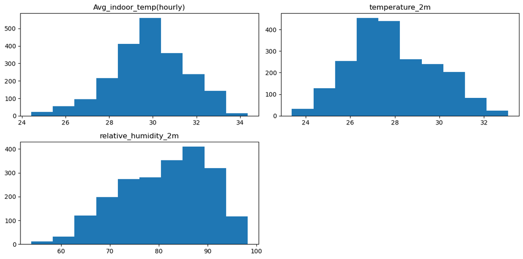

```python
fig = plt.figure(figsize = (12,6))

ax1 = fig.add_subplot(2,2,1)
ax1.hist(df_initial['Avg_indoor_temp(hourly)'])
ax1.set_title('Avg_indoor_temp(hourly)')

ax2 = fig.add_subplot(2,2,2)
ax2.hist(df_initial['temperature_2m'])
ax2.set_title('temperature_2m')

ax3 = fig.add_subplot(2,2,3)
ax3.hist(df_initial['relative_humidity_2m'])
ax3.set_title('relative_humidity_2m')

plt.tight_layout()
plt.show()
```

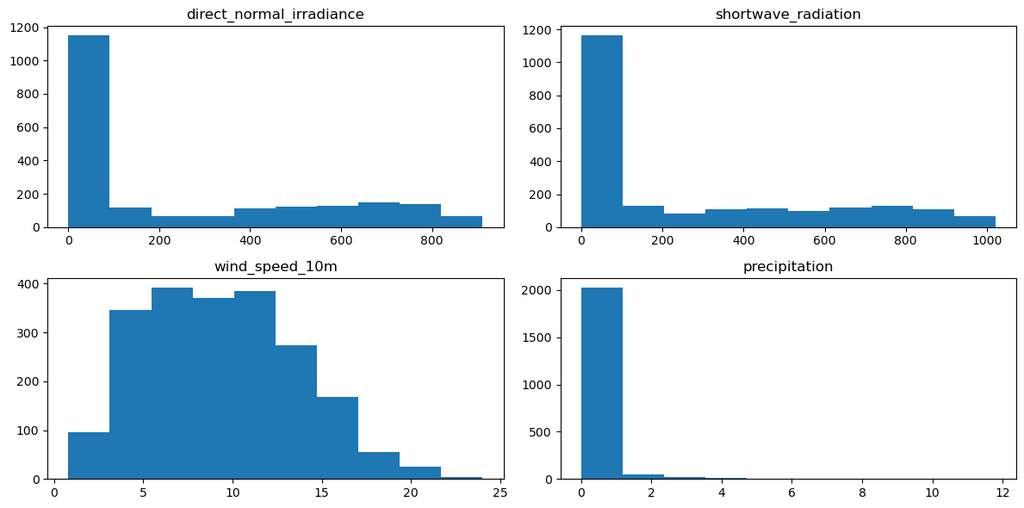

```python
fig = plt.figure(figsize = (12,6))

ax1 = fig.add_subplot(2,2,1)
ax1.hist(df_initial['direct_normal_irradiance'])
ax1.set_title('direct_normal_irradiance')

ax2 = fig.add_subplot(2,2,2)
ax2.hist(df_initial['shortwave_radiation'])
ax2.set_title('shortwave_radiation')

ax3 = fig.add_subplot(2,2,3)
ax3.hist(df_initial['wind_speed_10m'])
ax3.set_title('wind_speed_10m')

ax4 = fig.add_subplot(2,2,4)
ax4.hist(df_initial['precipitation'])
ax4.set_title('precipitation')

plt.tight_layout()
plt.show()
```

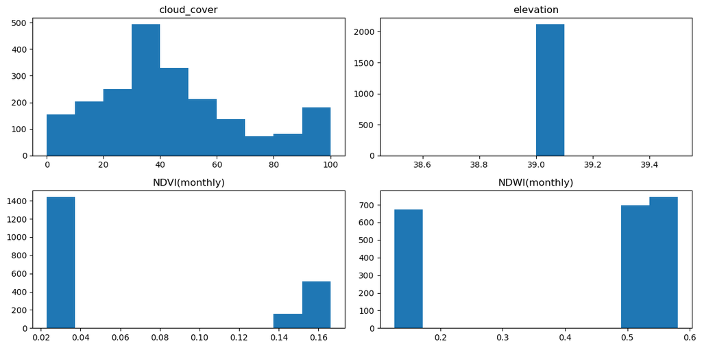

```python
fig = plt.figure(figsize = (12,6))

ax1 = fig.add_subplot(2,2,1)
ax1.hist(df_initial['cloud_cover'])
ax1.set_title('cloud_cover')

ax2 = fig.add_subplot(2,2,2)
ax2.hist(df_initial['elevation'])
ax2.set_title('elevation')

ax3 = fig.add_subplot(2,2,3)
ax3.hist(df_initial['NDVI(monthly)'])
ax3.set_title('NDVI(monthly)')

ax4 = fig.add_subplot(2,2,4)
ax4.hist(df_initial['NDWI(monthly)'])
ax4.set_title('NDWI(monthly)')

plt.tight_layout()
plt.show()
```

### **1.2. Distribution transformation to handle the skewed dataset**

```python
df_log = df_initial[['direct_normal_irradiance', 'shortwave_radiation', 'precipitation', 'NDVI(monthly)']]
```

```python
log_trf = FunctionTransformer(func=np.log1p)
df_log = log_trf.fit_transform(df_log)
```

```python
df_log.head()
```

|  | direct_normal_irradiance | shortwave_radiation | precipitation | NDVI(monthly) |
| --- | --- | --- | --- | --- |
| 0 | 6.466703 | 6.732211 | 0.000000 | 0.153579 |
| 1 | 6.706236 | 6.669498 | 0.000000 | 0.153579 |
| 2 | 4.468648 | 5.648974 | 0.587787 | 0.153579 |
| 3 | 6.157974 | 5.834811 | 0.095310 | 0.153579 |
| 4 | 5.805062 | 4.882802 | 0.000000 | 0.153579 |

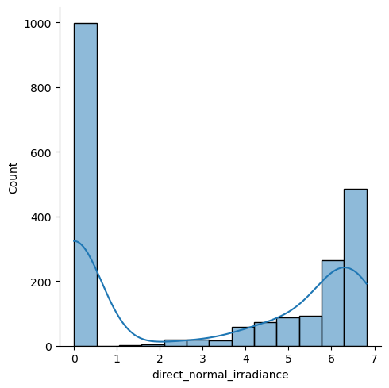

```python
sns.displot(data=df_log, x='direct_normal_irradiance', kde=True)
```

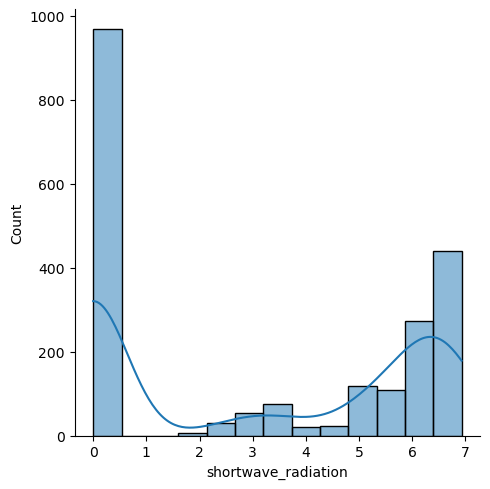

```python
sns.displot(data=df_log, x='shortwave_radiation', kde=True)
```

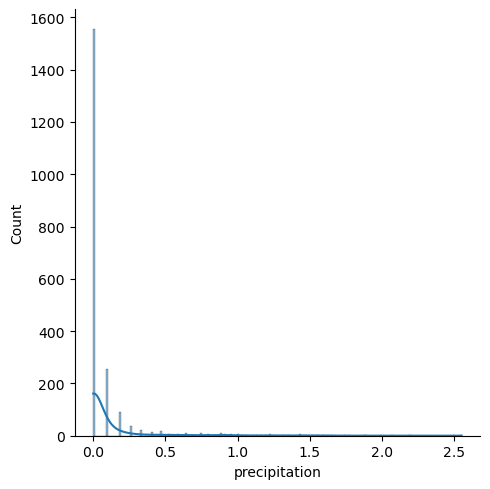

```python
sns.displot(data=df_log, x='precipitation', kde=True)
```

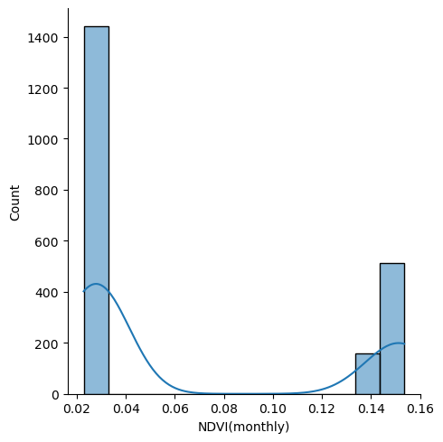

```python
sns.displot(data=df_log, x='NDVI(monthly)', kde=True)
```

```python
df_initial['direct_normal_irradiance'] = df_log['direct_normal_irradiance']
df_initial['shortwave_radiation'] = df_log['shortwave_radiation']
df_initial['precipitation'] = df_log['precipitation']
df_initial['NDVI(monthly)'] = df_log['NDVI(monthly)']
```

```python
df_initial.head(3)
```

|  | Date | Avg_indoor_temp(hourly) | school_latitude | school_longitude | temperature_2m | relative_humidity_2m | direct_normal_irradiance | shortwave_radiation | wind_speed_10m | precipitation | cloud_cover | elevation | NDVI(monthly) | NDWI(monthly) |
| --- | --- | --- | --- | --- | --- | --- | --- | --- | --- | --- | --- | --- | --- | --- |
| 0 | 2023-12-10 14:00:00 | 30.650000 | -6.886 | 39.28 | 28.085 | 78.22411 | 6.466703 | 6.732211 | 12.682018 | 0.000000 | 34.500000 | 39.0 | 0.153579 | 0.126 |
| 1 | 2023-12-10 15:00:00 | 31.116667 | -6.886 | 39.28 | 28.035 | 78.45239 | 6.706236 | 6.669498 | 12.783802 | 0.000000 | 28.799997 | 39.0 | 0.153579 | 0.126 |
| 2 | 2023-12-10 16:00:00 | 30.691666 | -6.886 | 39.28 | 26.085 | 86.13604 | 4.468648 | 5.648974 | 11.090103 | 0.587787 | 53.700000 | 39.0 | 0.153579 | 0.126 |

### **1.3. Define number of past and future timepoints for data preparation**

```python
# Define the number of past and future timepoints
#===========================================================================================================================
oneday_tps    = 24     # 1hr*24 = 1 day
n_past_days   = 5     # number of previous days data to be considered to predict temperature at next timepoints
n_future_days = 3      # number of future days data to be predicted

n_past_tps    = int(n_past_days*oneday_tps)    # number of previous time points data to be used, to predict the value for the next time point.
n_future_tps  = int(n_future_days*oneday_tps)     # Number of timepoints we want to forecast into the future based on the past timepoints
```

```python
print(n_past_tps, n_future_tps)
```

```
120 72
```

```python
df_initial.shape
```

```
(2114, 14)
```

### **1.4. Dataset to compare Future predictions**

```python
df_initial['Timepoint'] = df_initial.index
df_initial
```

|  | Date | Avg_indoor_temp(hourly) | school_latitude | school_longitude | temperature_2m | relative_humidity_2m | direct_normal_irradiance | shortwave_radiation | wind_speed_10m | precipitation | cloud_cover | elevation | NDVI(monthly) | NDWI(monthly) | Timepoint |
| --- | --- | --- | --- | --- | --- | --- | --- | --- | --- | --- | --- | --- | --- | --- | --- |
| 0 | 2023-12-10 14:00:00 | 30.650000 | -6.886 | 39.28 | 28.085000 | 78.224110 | 6.466703 | 6.732211 | 12.682018 | 0.000000 | 34.500000 | 39.0 | 0.153579 | 0.126 | 0 |
| 1 | 2023-12-10 15:00:00 | 31.116667 | -6.886 | 39.28 | 28.035000 | 78.452390 | 6.706236 | 6.669498 | 12.783802 | 0.000000 | 28.799997 | 39.0 | 0.153579 | 0.126 | 1 |
| 2 | 2023-12-10 16:00:00 | 30.691666 | -6.886 | 39.28 | 26.085000 | 86.136040 | 4.468648 | 5.648974 | 11.090103 | 0.587787 | 53.700000 | 39.0 | 0.153579 | 0.126 | 2 |
| 3 | 2023-12-10 17:00:00 | 30.258333 | -6.886 | 39.28 | 26.685000 | 83.390450 | 6.157974 | 5.834811 | 8.557102 | 0.095310 | 44.700005 | 39.0 | 0.153579 | 0.126 | 3 |
| 4 | 2023-12-10 18:00:00 | 29.416666 | -6.886 | 39.28 | 26.234999 | 85.118835 | 5.805062 | 4.882802 | 5.091168 | 0.000000 | 82.800000 | 39.0 | 0.153579 | 0.126 | 4 |
| ... | ... | ... | ... | ... | ... | ... | ... | ... | ... | ... | ... | ... | ... | ... | ... |
| 2109 | 2024-03-07 11:00:00 | 32.658333 | -6.886 | 39.28 | 31.335000 | 64.290650 | 6.695925 | 6.706862 | 7.421590 | 0.000000 | 20.099998 | 39.0 | 0.140631 | 0.160 | 2109 |
| 2110 | 2024-03-07 12:00:00 | 33.024998 | -6.886 | 39.28 | 31.984999 | 60.852050 | 6.646017 | 6.791221 | 9.064569 | 0.000000 | 24.300000 | 39.0 | 0.140631 | 0.160 | 2110 |
| 2111 | 2024-03-07 13:00:00 | 33.399998 | -6.886 | 39.28 | 32.335003 | 58.059460 | 6.674248 | 6.867974 | 10.086427 | 0.095310 | 20.700000 | 39.0 | 0.140631 | 0.160 | 2111 |
| 2112 | 2024-03-07 14:00:00 | 33.550000 | -6.886 | 39.28 | 32.685000 | 56.409695 | 6.660159 | 6.829794 | 11.252519 | 0.000000 | 15.600000 | 39.0 | 0.140631 | 0.160 | 2112 |
| 2113 | 2024-03-07 15:00:00 | 34.350000 | -6.886 | 39.28 | 32.535000 | 54.687073 | 6.662822 | 6.723832 | 12.605142 | 0.000000 | 12.600000 | 39.0 | 0.140631 | 0.160 | 2113 |

2114 rows × 15 columns

```python
df_future = df_initial[-n_future_tps:]
df_future.head(3)
```

|  | Date | Avg_indoor_temp(hourly) | school_latitude | school_longitude | temperature_2m | relative_humidity_2m | direct_normal_irradiance | shortwave_radiation | wind_speed_10m | precipitation | cloud_cover | elevation | NDVI(monthly) | NDWI(monthly) | Timepoint |
| --- | --- | --- | --- | --- | --- | --- | --- | --- | --- | --- | --- | --- | --- | --- | --- |
| 2042 | 2024-03-04 16:00:00 | 30.658333 | -6.886 | 39.28 | 30.785 | 67.343040 | 6.308812 | 6.440947 | 7.729527 | 0.0 | 38.7 | 39.0 | 0.140631 | 0.16 | 2042 |
| 2043 | 2024-03-04 17:00:00 | 28.824999 | -6.886 | 39.28 | 30.085 | 69.887695 | 6.363680 | 6.111467 | 9.693295 | 0.0 | 51.3 | 39.0 | 0.140631 | 0.16 | 2043 |
| 2044 | 2024-03-04 18:00:00 | 28.641668 | -6.886 | 39.28 | 28.785 | 75.785070 | 5.850800 | 5.220356 | 10.041354 | 0.0 | 53.7 | 39.0 | 0.140631 | 0.16 | 2044 |

```python
df_future.shape
```

```
(72, 15)
```

```python
df_initial = df_initial[:-n_future_tps]
df_initial.tail()
```

|  | Date | Avg_indoor_temp(hourly) | school_latitude | school_longitude | temperature_2m | relative_humidity_2m | direct_normal_irradiance | shortwave_radiation | wind_speed_10m | precipitation | cloud_cover | elevation | NDVI(monthly) | NDWI(monthly) | Timepoint |
| --- | --- | --- | --- | --- | --- | --- | --- | --- | --- | --- | --- | --- | --- | --- | --- |
| 2037 | 2024-03-04 11:00:00 | 30.666666 | -6.886 | 39.28 | 28.835 | 74.888000 | 3.936996 | 5.771441 | 13.661038 | 0.09531 | 39.000000 | 39.0 | 0.140631 | 0.16 | 2037 |
| 2038 | 2024-03-04 12:00:00 | 30.841667 | -6.886 | 39.28 | 30.435 | 69.534450 | 6.126865 | 6.697034 | 12.594856 | 0.00000 | 39.300003 | 39.0 | 0.140631 | 0.16 | 2038 |
| 2039 | 2024-03-04 13:00:00 | 31.074999 | -6.886 | 39.28 | 31.085 | 66.999240 | 5.837881 | 6.643790 | 10.144082 | 0.00000 | 47.100002 | 39.0 | 0.140631 | 0.16 | 2039 |
| 2040 | 2024-03-04 14:00:00 | 31.341667 | -6.886 | 39.28 | 30.885 | 67.565094 | 5.208147 | 6.453625 | 12.413477 | 0.00000 | 36.300003 | 39.0 | 0.140631 | 0.16 | 2040 |
| 2041 | 2024-03-04 15:00:00 | 31.433334 | -6.886 | 39.28 | 30.585 | 68.322296 | 5.461252 | 6.434547 | 11.709688 | 0.00000 | 46.500000 | 39.0 | 0.140631 | 0.16 | 2041 |

```python
df_initial.shape
```

```
(2042, 15)
```

```python
df = df_initial
```

## **2. Exploratory Data Aanalysis (EDA)**

**Features Description:**

'Avg_indoor_temp(hourly)', 'school_latitude', 'school_longitude', 'temperature_2m', 'relative_humidity_2m', 'direct_normal_irradiance', 'shortwave_radiation', 'wind_speed_10m', 'precipitation', 'cloud_cover', 'elevation', 'NDVI(monthly)', 'NDWI(monthly)

```python
mpl.rc('axes', labelsize=14)
mpl.rc('xtick', labelsize=12)
mpl.rc('ytick', labelsize=12)
font      = {'family':'arial', 'style':'normal', 'size':18}
axis_font = {'family':'arial', 'style':'normal', 'size':18}
plt.rc('font', **font)
```

### **2.1. Univariate Analysis**

#### **2.1.1. Histogram**

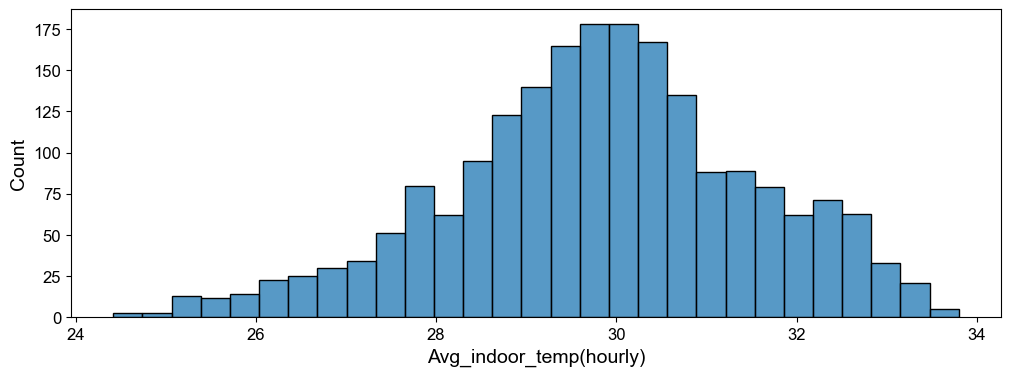

```python
plt.figure(figsize = (12,4))
sns.histplot(data=df,x='Avg_indoor_temp(hourly)')
```

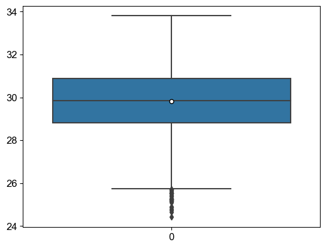

```python
sns.boxplot(df_initial['Avg_indoor_temp(hourly)'],showmeans=True, meanprops={"marker":"o","mfc":"white","ms":"5","mec":"black"})
```

### **2.2. Bivariate Analysis**

#### **2.2.1. Correlation matrix**

```python
df_corr = df_initial[['Avg_indoor_temp(hourly)', 'school_latitude', 'school_longitude',
                      'temperature_2m', 'relative_humidity_2m', 'direct_normal_irradiance',
                      'shortwave_radiation', 'wind_speed_10m', 'precipitation', 'cloud_cover',
                      'elevation', 'NDVI(monthly)','NDWI(monthly)']]
df_corr.head(3)
```

|  | Avg_indoor_temp(hourly) | school_latitude | school_longitude | temperature_2m | relative_humidity_2m | direct_normal_irradiance | shortwave_radiation | wind_speed_10m | precipitation | cloud_cover | elevation | NDVI(monthly) | NDWI(monthly) |
| --- | --- | --- | --- | --- | --- | --- | --- | --- | --- | --- | --- | --- | --- |
| 0 | 30.650000 | -6.886 | 39.28 | 28.085 | 78.22411 | 6.466703 | 6.732211 | 12.682018 | 0.000000 | 34.500000 | 39.0 | 0.153579 | 0.126 |
| 1 | 31.116667 | -6.886 | 39.28 | 28.035 | 78.45239 | 6.706236 | 6.669498 | 12.783802 | 0.000000 | 28.799997 | 39.0 | 0.153579 | 0.126 |
| 2 | 30.691666 | -6.886 | 39.28 | 26.085 | 86.13604 | 4.468648 | 5.648974 | 11.090103 | 0.587787 | 53.700000 | 39.0 | 0.153579 | 0.126 |

```python
# create cocorrelation matrix
corr_df = df_corr.corr().abs()
#mask = np.triu(np.ones_like(corr_df, dtype=bool))
#tri_df = corr_df.mask(mask)
#tri_df
corr_df
```

|  | Avg_indoor_temp(hourly) | school_latitude | school_longitude | temperature_2m | relative_humidity_2m | direct_normal_irradiance | shortwave_radiation | wind_speed_10m | precipitation | cloud_cover | elevation | NDVI(monthly) | NDWI(monthly) |
| --- | --- | --- | --- | --- | --- | --- | --- | --- | --- | --- | --- | --- | --- |
| Avg_indoor_temp(hourly) | 1.000000 | NaN | NaN | 0.706543 | 0.639427 | 0.493774 | 0.463331 | 0.349160 | 0.062394 | 0.262120 | NaN | 0.011502 | 0.117899 |
| school_latitude | NaN | NaN | NaN | NaN | NaN | NaN | NaN | NaN | NaN | NaN | NaN | NaN | NaN |
| school_longitude | NaN | NaN | NaN | NaN | NaN | NaN | NaN | NaN | NaN | NaN | NaN | NaN | NaN |
| temperature_2m | 0.706543 | NaN | NaN | 1.000000 | 0.938707 | 0.753095 | 0.762766 | 0.588643 | 0.079262 | 0.169454 | NaN | 0.016351 | 0.025403 |
| relative_humidity_2m | 0.639427 | NaN | NaN | 0.938707 | 1.000000 | 0.784789 | 0.799436 | 0.572374 | 0.038424 | 0.150406 | NaN | 0.005184 | 0.046686 |
| direct_normal_irradiance | 0.493774 | NaN | NaN | 0.753095 | 0.784789 | 1.000000 | 0.972503 | 0.501322 | 0.105365 | 0.084475 | NaN | 0.045957 | 0.057929 |
| shortwave_radiation | 0.463331 | NaN | NaN | 0.762766 | 0.799436 | 0.972503 | 1.000000 | 0.510516 | 0.176443 | 0.009059 | NaN | 0.013039 | 0.015372 |
| wind_speed_10m | 0.349160 | NaN | NaN | 0.588643 | 0.572374 | 0.501322 | 0.510516 | 1.000000 | 0.090828 | 0.046050 | NaN | 0.034555 | 0.038435 |
| precipitation | 0.062394 | NaN | NaN | 0.079262 | 0.038424 | 0.105365 | 0.176443 | 0.090828 | 1.000000 | 0.372840 | NaN | 0.043370 | 0.067508 |
| cloud_cover | 0.262120 | NaN | NaN | 0.169454 | 0.150406 | 0.084475 | 0.009059 | 0.046050 | 0.372840 | 1.000000 | NaN | 0.180137 | 0.229535 |
| elevation | NaN | NaN | NaN | NaN | NaN | NaN | NaN | NaN | NaN | NaN | NaN | NaN | NaN |
| NDVI(monthly) | 0.011502 | NaN | NaN | 0.016351 | 0.005184 | 0.045957 | 0.013039 | 0.034555 | 0.043370 | 0.180137 | NaN | 1.000000 | 0.968516 |
| NDWI(monthly) | 0.117899 | NaN | NaN | 0.025403 | 0.046686 | 0.057929 | 0.015372 | 0.038435 | 0.067508 | 0.229535 | NaN | 0.968516 | 1.000000 |

```python
mpl.rc('axes', labelsize=10)
mpl.rc('xtick', labelsize=10)
mpl.rc('ytick', labelsize=10)
font      = {'family':'arial', 'style':'normal', 'size':11}
axis_font = {'family':'arial', 'style':'normal', 'size':11}
plt.rc('font', **font)
```

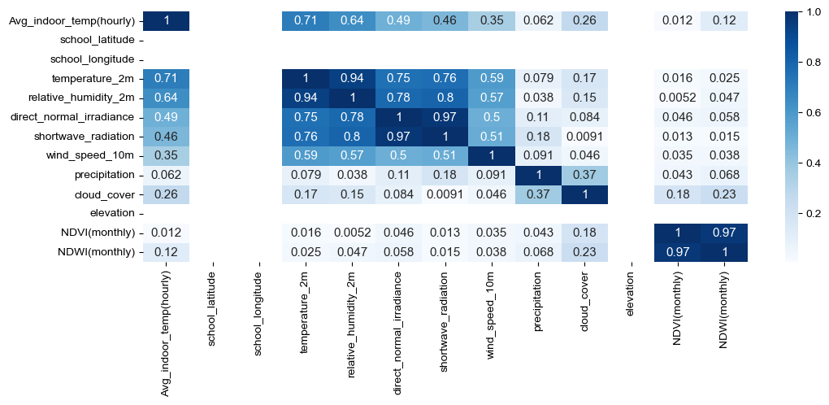

```python
plt.figure(figsize=(12, 4))
sns.heatmap(corr_df, annot=True, cmap='Blues')
plt.show()
```

**Observations:**

**"Avg_indoor_temp(hourly)" is having high Correlation (0.71) with Outside temperature (temperature_2m)**

req_cols = ['Date','Avg_indoor_temp(hourly)', 'school_latitude', 'school_longitude', 'temperature_2m', 'relative_humidity_2m', 'direct_normal_irradiance', 'shortwave_radiation', 'wind_speed_10m', 'precipitation', 'cloud_cover', 'elevation', 'NDVI(monthly)', 'NDWI(monthly)']

```python
df_initial.head(3)
```

|  | Date | Avg_indoor_temp(hourly) | school_latitude | school_longitude | temperature_2m | relative_humidity_2m | direct_normal_irradiance | shortwave_radiation | wind_speed_10m | precipitation | cloud_cover | elevation | NDVI(monthly) | NDWI(monthly) | Timepoint |
| --- | --- | --- | --- | --- | --- | --- | --- | --- | --- | --- | --- | --- | --- | --- | --- |
| 0 | 2023-12-10 14:00:00 | 30.650000 | -6.886 | 39.28 | 28.085 | 78.22411 | 6.466703 | 6.732211 | 12.682018 | 0.000000 | 34.500000 | 39.0 | 0.153579 | 0.126 | 0 |
| 1 | 2023-12-10 15:00:00 | 31.116667 | -6.886 | 39.28 | 28.035 | 78.45239 | 6.706236 | 6.669498 | 12.783802 | 0.000000 | 28.799997 | 39.0 | 0.153579 | 0.126 | 1 |
| 2 | 2023-12-10 16:00:00 | 30.691666 | -6.886 | 39.28 | 26.085 | 86.13604 | 4.468648 | 5.648974 | 11.090103 | 0.587787 | 53.700000 | 39.0 | 0.153579 | 0.126 | 2 |

```python
df_initial = df_initial.drop(columns=['school_latitude', 'school_longitude','elevation', 'precipitation'])
df_future = df_future.drop(columns=['school_latitude', 'school_longitude','elevation', 'precipitation'])
```

```python
df_initial.head(3)
```

|  | Date | Avg_indoor_temp(hourly) | temperature_2m | relative_humidity_2m | direct_normal_irradiance | shortwave_radiation | wind_speed_10m | cloud_cover | NDVI(monthly) | NDWI(monthly) | Timepoint |
| --- | --- | --- | --- | --- | --- | --- | --- | --- | --- | --- | --- |
| 0 | 2023-12-10 14:00:00 | 30.650000 | 28.085 | 78.22411 | 6.466703 | 6.732211 | 12.682018 | 34.500000 | 0.153579 | 0.126 | 0 |
| 1 | 2023-12-10 15:00:00 | 31.116667 | 28.035 | 78.45239 | 6.706236 | 6.669498 | 12.783802 | 28.799997 | 0.153579 | 0.126 | 1 |
| 2 | 2023-12-10 16:00:00 | 30.691666 | 26.085 | 86.13604 | 4.468648 | 5.648974 | 11.090103 | 53.700000 | 0.153579 | 0.126 | 2 |

```python
df_future.head(3)
```

|  | Date | Avg_indoor_temp(hourly) | temperature_2m | relative_humidity_2m | direct_normal_irradiance | shortwave_radiation | wind_speed_10m | cloud_cover | NDVI(monthly) | NDWI(monthly) | Timepoint |
| --- | --- | --- | --- | --- | --- | --- | --- | --- | --- | --- | --- |
| 2042 | 2024-03-04 16:00:00 | 30.658333 | 30.785 | 67.343040 | 6.308812 | 6.440947 | 7.729527 | 38.7 | 0.140631 | 0.16 | 2042 |
| 2043 | 2024-03-04 17:00:00 | 28.824999 | 30.085 | 69.887695 | 6.363680 | 6.111467 | 9.693295 | 51.3 | 0.140631 | 0.16 | 2043 |
| 2044 | 2024-03-04 18:00:00 | 28.641668 | 28.785 | 75.785070 | 5.850800 | 5.220356 | 10.041354 | 53.7 | 0.140631 | 0.16 | 2044 |

#### **2.2.2 Pair Plots**

```python
#plt.figure(figsize=(12,8))
#sns.pairplot(df_corr)
```

## **3. Data Preparation for LSTM model**

### **3.1 Creating Training, Validation and Testing sets**

- here previous *no_prev_timepoints* (the number of previous timepoints’ data to use) are used to predict the value for the next timepoint.
- *no_prev_timepoints* are required before the 1st date in the validation and test dataset.
- Accordingly, create input data for validation prediciton and testing prediction, index starting from the date *no_prev_timepoints* days before the first date in the validation or test dataset.

```python
# number of previous time points data to be used, to predict the value for the next time point.
no_prev_timepoints = n_past_tps
train_percent = 0.80       # percentage of data for training
# Note : remaining percentage will be used for validation
#===========================================================================================================
# copy the selected columns in to a dataframe
df = df_initial[['Avg_indoor_temp(hourly)','temperature_2m','relative_humidity_2m',
                 'direct_normal_irradiance','shortwave_radiation', 'wind_speed_10m',
                 'cloud_cover','NDVI(monthly)', 'NDWI(monthly)']].values

# copy the date column which will be used later for plotting
df_date = df_initial['Date']
#============================================================================================================

# split the data in to training & validation
train_split = int(len(df)*train_percent)

train_set = df[:train_split]      # training dataset
val_set   = df[train_split:]      # validation dataset

val_set_4generator  = df[train_split-no_prev_timepoints:]   # only for timeseries generator, validation dataset

#=============================================================================================================
date_train = df_initial['Date'][:train_split]          # used for plotting. Dates corresponding to training data
date_val = df_initial['Date'][train_split:]

timepoint_train = df_initial['Timepoint'][:train_split]          # used for plotting. Dates corresponding to training data
timepoint_val = df_initial['Timepoint'][train_split:]

date_val_4generator  = df_initial['Date'][train_split-no_prev_timepoints:]   # used for plotting. Dates corresponding to validation data
timepoint_val_4generator  = df_initial['Timepoint'][train_split-no_prev_timepoints:]   # used for plotting. Dates corresponding to validation data

#=============================================================================================================
print("Full dataset length                  : ", len(df))
print("Training set length                  : ", len(train_set))
print("Validation set length                : ", len(val_set))

print("no_prev_timepoints                   : ", no_prev_timepoints)
print("Validation set length (for generator): ", len(val_set_4generator))
print(len(train_set)+len(val_set))
```

```
Full dataset length                  :  2042
Training set length                  :  1633
Validation set length                :  409
no_prev_timepoints                   :  120
Validation set length (for generator):  529
2042
```

```python
df_initial.head(3)
```

|  | Date | Avg_indoor_temp(hourly) | temperature_2m | relative_humidity_2m | direct_normal_irradiance | shortwave_radiation | wind_speed_10m | cloud_cover | NDVI(monthly) | NDWI(monthly) | Timepoint |
| --- | --- | --- | --- | --- | --- | --- | --- | --- | --- | --- | --- |
| 0 | 2023-12-10 14:00:00 | 30.650000 | 28.085 | 78.22411 | 6.466703 | 6.732211 | 12.682018 | 34.500000 | 0.153579 | 0.126 | 0 |
| 1 | 2023-12-10 15:00:00 | 31.116667 | 28.035 | 78.45239 | 6.706236 | 6.669498 | 12.783802 | 28.799997 | 0.153579 | 0.126 | 1 |
| 2 | 2023-12-10 16:00:00 | 30.691666 | 26.085 | 86.13604 | 4.468648 | 5.648974 | 11.090103 | 53.700000 | 0.153579 | 0.126 | 2 |

```python
df[:2]
```

```
array([[30.65      , 28.085     , 78.22411   ,  6.46670336,  6.73221071,
        12.682018  , 34.5       ,  0.15357909,  0.126     ],
       [31.116667  , 28.035     , 78.45239   ,  6.70623598,  6.66949809,
        12.783802  , 28.799997  ,  0.15357909,  0.126     ]])
```

```python
train_set[:2]
```

```
array([[30.65      , 28.085     , 78.22411   ,  6.46670336,  6.73221071,
        12.682018  , 34.5       ,  0.15357909,  0.126     ],
       [31.116667  , 28.035     , 78.45239   ,  6.70623598,  6.66949809,
        12.783802  , 28.799997  ,  0.15357909,  0.126     ]])
```

```python
df[train_split:train_split+2]
```

```
array([[3.30833320e+01, 3.18850000e+01, 6.32571800e+01, 6.62307983e+00,
        6.69703425e+00, 1.60755210e+01, 2.34000000e+01, 2.27394870e-02,
        5.00000000e-01],
       [3.27833330e+01, 3.16350000e+01, 6.13271370e+01, 6.55885319e+00,
        6.48463524e+00, 1.64854850e+01, 2.81999990e+01, 2.27394870e-02,
        5.00000000e-01]])
```

```python
val_set[:2]
```

```
array([[3.30833320e+01, 3.18850000e+01, 6.32571800e+01, 6.62307983e+00,
        6.69703425e+00, 1.60755210e+01, 2.34000000e+01, 2.27394870e-02,
        5.00000000e-01],
       [3.27833330e+01, 3.16350000e+01, 6.13271370e+01, 6.55885319e+00,
        6.48463524e+00, 1.64854850e+01, 2.81999990e+01, 2.27394870e-02,
        5.00000000e-01]])
```

### **3.2. Visualize the Data**

#### **3.2.1. Storing the data for reference**

```python
df_initial.to_csv("df_initial.csv")
df_future.to_csv("df_future.csv")
```

```python
['Avg_indoor_temp(hourly)', 'school_latitude', 'school_longitude',
                  'temperature_2m','relative_humidity_2m', 'direct_normal_irradiance',
                  'shortwave_radiation', 'wind_speed_10m', 'cloud_cover',
                  'elevation', 'NDVI(monthly)', 'NDWI(monthly)']
```

```
['Avg_indoor_temp(hourly)',
 'school_latitude',
 'school_longitude',
 'temperature_2m',
 'relative_humidity_2m',
 'direct_normal_irradiance',
 'shortwave_radiation',
 'wind_speed_10m',
 'cloud_cover',
 'elevation',
 'NDVI(monthly)',
 'NDWI(monthly)']
```

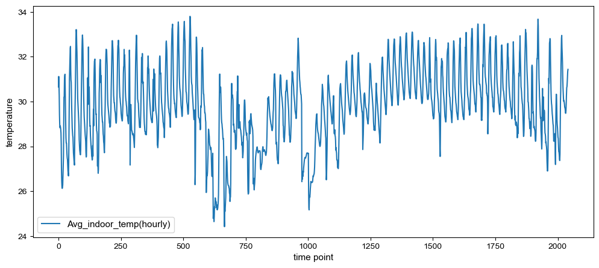

```python
# 1) Avg_indoor_temp(hourly)
#===========================================================================
fig = plt.figure(figsize=(12, 5))
#plt.plot(df_initial["Date"], df_initial["Avg_indoor_temp(hourly)"], label='Avg_indoor_temp(hourly)')
plt.plot(df_initial["Avg_indoor_temp(hourly)"].values, label='Avg_indoor_temp(hourly)')
plt.xlabel("time point", axis_font)
plt.ylabel("temperature", axis_font)
plt.legend()
plt.show()
```

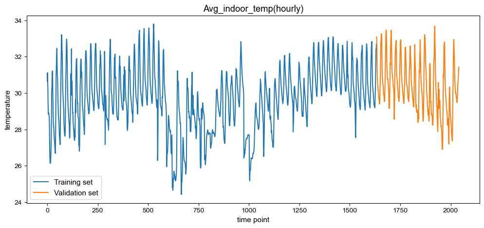

```python
# 1) Avg_indoor_temp(hourly)
# Plot train and validation
#===========================================================================
fig = plt.figure(figsize=(12, 5))
plt.plot(timepoint_train,train_set[:, 0], label='Training set')
plt.plot(timepoint_val,val_set[:, 0], label='Validation set')

#plt.plot(train_set[:, 0], label='Training set')
#plt.plot(val_set[:, 0], label='Validation set')

plt.title('Avg_indoor_temp(hourly)')
plt.xlabel("time point", axis_font)
plt.ylabel("temperature", axis_font)
#plt.xlim([datetime.date(2024, 1, 15), datetime.date(2020, 1, 20)])
plt.legend()
plt.show()
```

```python
timepoint_train[-5:]
```

```
1628    1628
1629    1629
1630    1630
1631    1631
1632    1632
Name: Timepoint, dtype: int64
```

```python
timepoint_val[-5:]
```

```
2037    2037
2038    2038
2039    2039
2040    2040
2041    2041
Name: Timepoint, dtype: int64
```

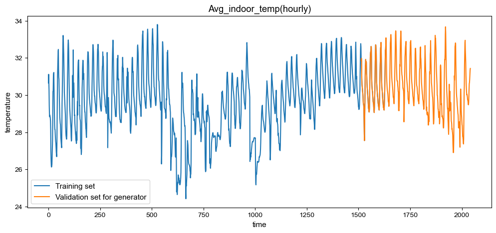

```python
# Avg_indoor_temp(hourly)
# Plot train & validation for Timeseries generator
#===========================================================================
plt.figure(figsize=(12,5))
plt.plot(timepoint_train,train_set[:,0], label='Training set')
plt.plot(timepoint_val_4generator,val_set_4generator[:,0], label='Validation set for generator')
plt.title('Avg_indoor_temp(hourly)')
plt.xlabel("time", axis_font)
plt.ylabel("temperature", axis_font)
#plt.xlim([datetime.date(2024, 2, 10), datetime.date(2024, 2, 20)])
plt.legend()
plt.show()
```

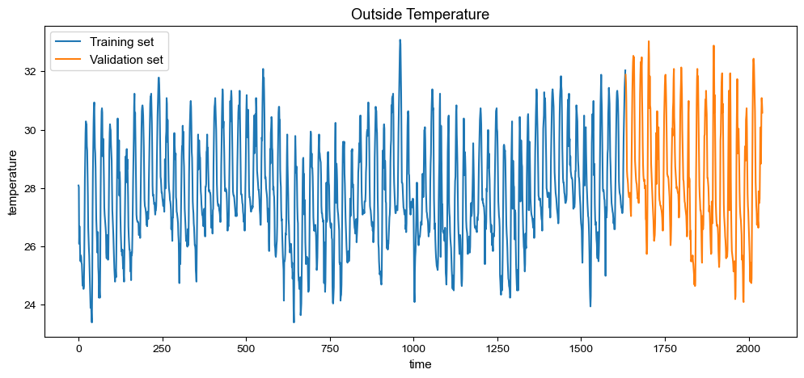

```python
# temperature_2m : outside temperature
#===========================================================================
fig = plt.figure(figsize=(12, 5))
plt.plot(timepoint_train,train_set[:, 1], label='Training set')
plt.plot(timepoint_val,val_set[:, 1], label='Validation set')
plt.title('Outside Temperature')
plt.xlabel("time", axis_font)
plt.ylabel("temperature", axis_font)
plt.legend()
plt.show()
```

### **3.3. Normalize the Data**

```python
# Fit and Transform training set
X_scaler = MinMaxScaler(feature_range=(0,1))

train_set_scaled = X_scaler.fit_transform(train_set)
#===========================================================================
# Transform validation and testing sets
val_set_scaled = X_scaler.transform(val_set_4generator)
```

```python
train_set_scaled.shape, val_set_scaled.shape
```

```
((1633, 9), (529, 9))
```

```python
df_initial.head(3)
```

|  | Date | Avg_indoor_temp(hourly) | temperature_2m | relative_humidity_2m | direct_normal_irradiance | shortwave_radiation | wind_speed_10m | cloud_cover | NDVI(monthly) | NDWI(monthly) | Timepoint |
| --- | --- | --- | --- | --- | --- | --- | --- | --- | --- | --- | --- |
| 0 | 2023-12-10 14:00:00 | 30.650000 | 28.085 | 78.22411 | 6.466703 | 6.732211 | 12.682018 | 34.500000 | 0.153579 | 0.126 | 0 |
| 1 | 2023-12-10 15:00:00 | 31.116667 | 28.035 | 78.45239 | 6.706236 | 6.669498 | 12.783802 | 28.799997 | 0.153579 | 0.126 | 1 |
| 2 | 2023-12-10 16:00:00 | 30.691666 | 26.085 | 86.13604 | 4.468648 | 5.648974 | 11.090103 | 53.700000 | 0.153579 | 0.126 | 2 |

```python
train_set[:2]
```

```
array([[30.65      , 28.085     , 78.22411   ,  6.46670336,  6.73221071,
        12.682018  , 34.5       ,  0.15357909,  0.126     ],
       [31.116667  , 28.035     , 78.45239   ,  6.70623598,  6.66949809,
        12.783802  , 28.799997  ,  0.15357909,  0.126     ]])
```

```python
train_set_scaled[:2]
```

```
array([[0.66429843, 0.48453593, 0.54873707, 0.94872294, 0.97152672,
        0.55375589, 0.345     , 1.        , 0.        ],
       [0.71403203, 0.4793813 , 0.55388822, 0.9838645 , 0.96247665,
        0.55850147, 0.28799997, 1.        , 0.        ]])
```

```python
val_set[:2]
```

```
array([[3.30833320e+01, 3.18850000e+01, 6.32571800e+01, 6.62307983e+00,
        6.69703425e+00, 1.60755210e+01, 2.34000000e+01, 2.27394870e-02,
        5.00000000e-01],
       [3.27833330e+01, 3.16350000e+01, 6.13271370e+01, 6.55885319e+00,
        6.48463524e+00, 1.64854850e+01, 2.81999990e+01, 2.27394870e-02,
        5.00000000e-01]])
```

```python
val_set_scaled[:2]
```

```
array([[0.7930727 , 0.68041206, 0.36495228, 0.97047073, 0.96733846,
        0.65145816, 0.27599998, 0.        , 0.82197802],
       [0.80550623, 0.69072144, 0.32312502, 0.97130265, 0.94035317,
        0.54511644, 0.114     , 0.        , 0.82197802]])
```

### **3.4. Define TimeseriesGenerator for training, validation and testing sets**

- here previous *no_prev_timepoints* (the number of previous timepoints’ data to use) are used to predict the value for the next timepoint.
- *no_prev_timepoints* are required before the 1st date in the validation and test dataset.
- Accordingly, create input data for validation prediciton and testing prediction, index starting from the date *no_prev_timepoints* days before the first date in the validation or test dataset.

```python
train_set_scaled.shape, val_set_scaled.shape
```

```
((1633, 9), (529, 9))
```

```python
#=========================================================================================
# 1. Training dataset : train_set_scaled
#=========================================================================================
df = train_set_scaled

#As required for LSTM networks, we require to reshape an input data into (number of samples X timesteps X number of features)

trainX = []  # list to store input features
trainY = []  # list to store target label

# Reformat input data into a shape: (n_samples x timesteps x n_features)
for i in range(n_past_tps, len(df) - n_future_tps +1):
    trainX.append(df[i - n_past_tps:i, 0:df.shape[1]])
    trainY.append(df[i :i + n_future_tps, 0])           # target column is in 0th column (Tair)

trainX, trainY = np.array(trainX), np.array(trainY)

print("Full dataset length : ", len(df))
print("trainX shape        :", trainX.shape)
print("trainY shape        :", trainY.shape)
```

```
Full dataset length :  1633
trainX shape        : (1442, 120, 9)
trainY shape        : (1442, 72)
```

```python
train_set_scaled[-6:]
```

```
array([[0.61722923, 0.65463887, 0.37823923, 0.95397476, 0.87098158,
        0.67378998, 0.28500002, 0.        , 0.82197802],
       [0.69449388, 0.71649462, 0.31497317, 0.96165669, 0.92433985,
        0.7586352 , 0.318     , 0.        , 0.82197802],
       [0.78685625, 0.79381419, 0.25070959, 0.98672075, 0.97118231,
        0.81782816, 0.33      , 0.        , 0.82197802],
       [0.85257564, 0.82989665, 0.213132  , 0.96920968, 0.97841193,
        0.85962433, 0.462     , 0.        , 0.82197802],
       [0.85079909, 0.86082437, 0.21457761, 0.9612163 , 0.98309093,
        0.79580653, 0.32100002, 0.        , 0.82197802],
       [0.88099475, 0.8917523 , 0.19893096, 0.97928206, 0.98466983,
        0.72075657, 0.357     , 0.        , 0.82197802]])
```

```python
trainX[-1:].shape    # number of samples X number of past time points X number of futures
```

```
(1, 120, 9)
```

```python
trainX[-1:]
```

```
array([[[0.88188271, 0.83505119, 0.31086147, ..., 0.42300003,
         0.        , 0.82197802],
        [0.88543539, 0.81958738, 0.32855067, ..., 0.25199999,
         0.        , 0.82197802],
        [0.8561279 , 0.73195843, 0.37653638, ..., 0.17400002,
         0.        , 0.82197802],
        ...,
        [0.83303738, 0.768041  , 0.3356555 , ..., 0.23699999,
         0.        , 0.82197802],
        [0.84458264, 0.82474201, 0.29226697, ..., 0.13799999,
         0.        , 0.82197802],
        [0.84369436, 0.87628839, 0.21529893, ..., 0.171     ,
         0.        , 0.82197802]]])
```

```python
trainY[-1:].shape   # equal to number of future time points
```

```
(1, 72)
```

```python
trainY[-1:]
```

```
array([[0.87388971, 0.86944939, 0.76554154, 0.68916517, 0.65008898,
        0.63055072, 0.61811729, 0.61456493, 0.5888099 , 0.57371239,
        0.55417413, 0.5523979 , 0.53996437, 0.51865009, 0.5053286 ,
        0.49467151, 0.52309051, 0.57637648, 0.6047958 , 0.68472475,
        0.78774431, 0.83836587, 0.88365884, 0.88099475, 0.8534636 ,
        0.83481351, 0.73889878, 0.66785089, 0.64564834, 0.62699836,
        0.6074601 , 0.58969797, 0.58170518, 0.56749563, 0.54795747,
        0.54085264, 0.53285964, 0.52309051, 0.51865009, 0.50888117,
        0.53552394, 0.57193605, 0.65008898, 0.72024879, 0.77619884,
        0.8143873 , 0.86678509, 0.8721139 , 0.89698033, 0.84458264,
        0.76376563, 0.68561281, 0.64209587, 0.62699836, 0.61278859,
        0.5994671 , 0.57548841, 0.56305499, 0.54795747, 0.53197158,
        0.52220245, 0.52131428, 0.51332138, 0.50888117, 0.53374792,
        0.59147431, 0.61722923, 0.69449388, 0.78685625, 0.85257564,
        0.85079909, 0.88099475]])
```

```python
#=========================================================================================
# 2. Validation dataset : val_set_scaled
#=========================================================================================
df = val_set_scaled

#As required for LSTM networks, we require to reshape an input data into (number of samples X timesteps X number of features)

valX = []  # list to store input features
valY = []  # list to store target label

# Reformat input data into a shape: (n_samples x timesteps x n_features)
for i in range(n_past_tps, len(df) - n_future_tps +1):
    valX.append(df[i - n_past_tps:i, 0:df.shape[1]])
    valY.append(df[i :i + n_future_tps, 0])           # target column is in 0th column (Tair)

valX, valY = np.array(valX), np.array(valY)

print("Full dataset length : ", len(df))
print("valX shape          :", valX.shape)
print("valY shape          :", valY.shape)
```

```
Full dataset length :  529
valX shape          : (338, 120, 9)
valY shape          : (338, 72)
```

```python
val_set_scaled[:5]
```

```
array([[0.7930727 , 0.68041206, 0.36495228, 0.97047073, 0.96733846,
        0.65145816, 0.27599998, 0.        , 0.82197802],
       [0.80550623, 0.69072144, 0.32312502, 0.97130265, 0.94035317,
        0.54511644, 0.114     , 0.        , 0.82197802],
       [0.79040861, 0.60309249, 0.41996599, 0.95320522, 0.88479856,
        0.59696448, 0.25199999, 0.        , 0.82197802],
       [0.69182947, 0.54639158, 0.49849124, 0.90621271, 0.77769806,
        0.59585343, 0.09      , 0.        , 0.82197802],
       [0.6545294 , 0.48453593, 0.54873707, 0.71788236, 0.51713836,
        0.53042547, 0.078     , 0.        , 0.82197802]])
```

```python
valX[:1]
```

```
array([[[0.7930727 , 0.68041206, 0.36495228, ..., 0.27599998,
         0.        , 0.82197802],
        [0.80550623, 0.69072144, 0.32312502, ..., 0.114     ,
         0.        , 0.82197802],
        [0.79040861, 0.60309249, 0.41996599, ..., 0.25199999,
         0.        , 0.82197802],
        ...,
        [0.85257564, 0.82989665, 0.213132  , ..., 0.462     ,
         0.        , 0.82197802],
        [0.85079909, 0.86082437, 0.21457761, ..., 0.32100002,
         0.        , 0.82197802],
        [0.88099475, 0.8917523 , 0.19893096, ..., 0.357     ,
         0.        , 0.82197802]]])
```

```python
valY[:1]
```

```
array([[0.92362331, 0.89165184, 0.80728246, 0.71758439, 0.67495562,
        0.6492007 , 0.62877438, 0.61811729, 0.61190052, 0.6021314 ,
        0.58436948, 0.55861456, 0.55595026, 0.54884543, 0.53019524,
        0.53730028, 0.56749563, 0.63055072, 0.64742457, 0.73357029,
        0.82770836, 0.89342807, 0.90497333, 0.93960931, 0.94227372,
        0.92007105, 0.84902328, 0.75044414, 0.6962699 , 0.67673196,
        0.66429864, 0.65097693, 0.63765544, 0.62433395, 0.60301946,
        0.58436948, 0.58525754, 0.57460024, 0.5577265 , 0.54529307,
        0.57371239, 0.6101245 , 0.66252219, 0.74333941, 0.79040861,
        0.86056875, 0.93960931, 0.96358778, 0.96269983, 0.89698033,
        0.85523973, 0.74955586, 0.71225579, 0.68117238, 0.67584368,
        0.67761992, 0.66873885, 0.6492007 , 0.63765544, 0.61545289,
        0.61456493, 0.50621666, 0.5106573 , 0.5053286 , 0.53108351,
        0.59680269, 0.68738905, 0.77087035, 0.76021327, 0.8534636 ,
        0.89964484, 0.93339254]])
```

## **4. Build RNN - LSTM Model**

### **4.1. Create LSTM Model**

```python
num_features = train_set_scaled.shape[1]
#===========================================================================
#1st LSTM layer
# Note : if the activation function is "relu" then will get the following
# WARNING:tensorflow:Layer LSTM_1 will not use cuDNN kernels since it doesn't meet the criteria.

with tf.device('/device:GPU:0'):
    model = Sequential()

    #model.add(GaussianNoise(0.1, input_shape = (no_prev_timepoints, num_features)))
    #model.add(LSTM(units=128, return_sequences=False, name='LSTM_1'))
    model.add(LSTM(units=128, input_shape = (no_prev_timepoints, num_features), return_sequences=True, name='LSTM_1'))

    model.add(LSTM(units=128, name='LSTM_2'))

    # Output layer
    model.add(Dense(trainY.shape[1], name='Output'))

model.summary()
```

```
Model: "sequential"
_________________________________________________________________
 Layer (type)                Output Shape              Param #
=================================================================
 LSTM_1 (LSTM)               (None, 120, 128)          70656

 LSTM_2 (LSTM)               (None, 128)               131584

 Output (Dense)              (None, 72)                9288

=================================================================
Total params: 211,528
Trainable params: 211,528
Non-trainable params: 0
_________________________________________________________________
```

### **4.2. Compile the model**

```python
#sgd = SGD(learning_rate=0.01, momentum=0.9)
#model.compile(optimizer=sgd, loss='mean_squared_error')
```

```python
model.compile(optimizer='adam', loss='mean_squared_error')
```

### **4.3. Train the Model**

```python
num_epochs = 100

early_stopping = EarlyStopping(monitor='val_loss', mode='min', patience=3)

with tf.device('/device:GPU:0'):
    training = model.fit(trainX,trainY, validation_data=(valX,valY), batch_size=2,
                         epochs=num_epochs, callbacks=[early_stopping])
```

num_epochs = 100

early_stopping = EarlyStopping(monitor='val_loss', mode='min', patience=5)

with tf.device('/device:GPU:0'): training = model.fit(trainX,trainY, validation_data=(valX,valY), epochs=num_epochs, batch_size=32, shuffle=False, callbacks=[early_stopping])

### **4.4. Plot the Loss history**

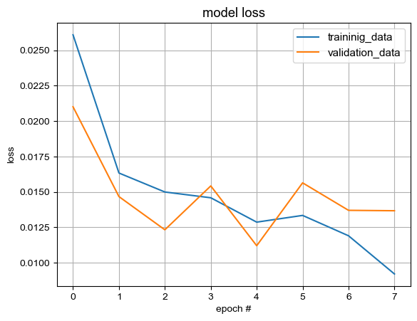

```python
plt.plot(training.history['loss'], label='traininig_data')
plt.plot(training.history['val_loss'], label='validation_data')
plt.legend()
plt.title("model loss")
plt.xlabel("epoch #")
plt.ylabel("loss")
plt.grid()
plt.show()
```

```python
type(date_train)
```

```
pandas.core.series.Series
```

```python
type(train_set)
```

```
numpy.ndarray
```

```python
train_set_scaled.shape
```

```
(1633, 9)
```

### **4.5. Prediction for Validation data**

```python
# Since for the first "no_prev_timepoints" there won't be predictable values,
# hence in order to compare the original training data labels with predicted labels,
# we need to subtract the "no_prev_timepoints" from original training dataset
#==================================================================================================
sub_tps = no_prev_timepoints

train_set_plot = X_scaler.inverse_transform(train_set_scaled)
train_set_plot = train_set_plot[sub_tps:-1]

date_train_plot = date_train[sub_tps:-1]
#==================================================================================================
date_val_plot = date_val[:-1]
val_set_plot = val_set[:-1]
```

```python
train_set_plot.shape
```

```
(1512, 9)
```

```python
train_set_plot[:2]
```

```
array([[32.433334  , 28.335     , 79.20363   ,  5.86317582,  6.4738907 ,
         6.489992  , 68.7       ,  0.15357909,  0.126     ],
       [30.691666  , 29.635     , 73.4619    ,  6.47777973,  6.58617165,
         5.3999996 , 56.4       ,  0.15357909,  0.126     ]])
```

```python
date_train_plot[:5]
```

```
120   2023-12-15 14:00:00
121   2023-12-15 15:00:00
122   2023-12-15 16:00:00
123   2023-12-15 17:00:00
124   2023-12-15 18:00:00
Name: Date, dtype: datetime64[ns]
```

```python
train_predict = model.predict(trainX)
val_predict = model.predict(valX)
```

```python
train_predict
```

```
array([[0.707001  , 0.6908803 , 0.646613  , ..., 0.70137393, 0.7666985 ,
        0.7927651 ],
       [0.7049198 , 0.6710513 , 0.6153368 , ..., 0.7774353 , 0.8213203 ,
        0.8300726 ],
       [0.6654511 , 0.61472404, 0.5663682 , ..., 0.8116489 , 0.8329078 ,
        0.8215823 ],
       ...,
       [0.82580155, 0.8260257 , 0.84594953, ..., 0.66745436, 0.7204648 ,
        0.78153515],
       [0.8565965 , 0.83656913, 0.8397366 , ..., 0.72018397, 0.7708248 ,
        0.8183247 ],
       [0.8655659 , 0.830341  , 0.8183078 , ..., 0.76818913, 0.80896777,
        0.8359789 ]], dtype=float32)
```

```python
trainX.shape, train_predict.shape
```

```
((1442, 120, 9), (1442, 72))
```

```python
# temporarly defining a minmax scaler for the Tair with the same shape as "number of respective samples" X "n_future_tps"
# this will help us to inverse scaling of predicted labels with the same shape as "number of respective samples" X "n_future_tps"
```

```python
Tair = train_set[:, 0]
Tair
```

```
array([30.65    , 31.116667, 30.691666, ..., 32.416668, 32.399998,
       32.683334])
```

```python
Tair = Tair.reshape(-1,1)
Tair
```

```
array([[30.65    ],
       [31.116667],
       [30.691666],
       ...,
       [32.416668],
       [32.399998],
       [32.683334]])
```

```python
Tair.shape
```

```
(1633, 1)
```

```python
Tair = np.repeat(Tair, n_future_tps, axis=-1)
Tair
```

```
array([[30.65    , 30.65    , 30.65    , ..., 30.65    , 30.65    ,
        30.65    ],
       [31.116667, 31.116667, 31.116667, ..., 31.116667, 31.116667,
        31.116667],
       [30.691666, 30.691666, 30.691666, ..., 30.691666, 30.691666,
        30.691666],
       ...,
       [32.416668, 32.416668, 32.416668, ..., 32.416668, 32.416668,
        32.416668],
       [32.399998, 32.399998, 32.399998, ..., 32.399998, 32.399998,
        32.399998],
       [32.683334, 32.683334, 32.683334, ..., 32.683334, 32.683334,
        32.683334]])
```

```python
Tair_scaler = MinMaxScaler(feature_range=(0,1))
```

```python
Tair_scaled = Tair_scaler.fit_transform(Tair)
Tair_scaled
```

```
array([[0.66429843, 0.66429843, 0.66429843, ..., 0.66429843, 0.66429843,
        0.66429843],
       [0.71403203, 0.71403203, 0.71403203, ..., 0.71403203, 0.71403203,
        0.71403203],
       [0.66873885, 0.66873885, 0.66873885, ..., 0.66873885, 0.66873885,
        0.66873885],
       ...,
       [0.85257564, 0.85257564, 0.85257564, ..., 0.85257564, 0.85257564,
        0.85257564],
       [0.85079909, 0.85079909, 0.85079909, ..., 0.85079909, 0.85079909,
        0.85079909],
       [0.88099475, 0.88099475, 0.88099475, ..., 0.88099475, 0.88099475,
        0.88099475]])
```

```python
# Perform inverse transformation to rescale back to original range
# Since 7 variables were used for transform, the inverse expects same dimensions
# Therefore, copy values 7 times and discard them after inverse transform
#=============================================================================================
train_predict = Tair_scaler.inverse_transform(train_predict)

val_predict = Tair_scaler.inverse_transform(val_predict)
```

```python
date_train_plot.shape, train_set_plot.shape, train_predict.shape
```

```
((1512,), (1512, 9), (1442, 72))
```

```python
date_val_plot.shape, val_set_plot.shape, val_predict.shape
```

```
((408,), (408, 9), (338, 72))
```

## **5. Future Forecasting**

```python
df_initial.tail(3)
```

|  | Date | Avg_indoor_temp(hourly) | temperature_2m | relative_humidity_2m | direct_normal_irradiance | shortwave_radiation | wind_speed_10m | cloud_cover | NDVI(monthly) | NDWI(monthly) | Timepoint |
| --- | --- | --- | --- | --- | --- | --- | --- | --- | --- | --- | --- |
| 2039 | 2024-03-04 13:00:00 | 31.074999 | 31.085 | 66.999240 | 5.837881 | 6.643790 | 10.144082 | 47.100002 | 0.140631 | 0.16 | 2039 |
| 2040 | 2024-03-04 14:00:00 | 31.341667 | 30.885 | 67.565094 | 5.208147 | 6.453625 | 12.413477 | 36.300003 | 0.140631 | 0.16 | 2040 |
| 2041 | 2024-03-04 15:00:00 | 31.433334 | 30.585 | 68.322296 | 5.461252 | 6.434547 | 11.709688 | 46.500000 | 0.140631 | 0.16 | 2041 |

```python
val_set[-3:]
```

```
array([[31.074999  , 31.085     , 66.99924   ,  5.83788116,  6.64378973,
        10.144082  , 47.100002  ,  0.14063113,  0.16      ],
       [31.341667  , 30.885     , 67.565094  ,  5.20814684,  6.453625  ,
        12.413477  , 36.300003  ,  0.14063113,  0.16      ],
       [31.433334  , 30.585     , 68.322296  ,  5.46125187,  6.43454652,
        11.709688  , 46.5       ,  0.14063113,  0.16      ]])
```

```python
input_for_future_pred = val_set[-no_prev_timepoints:]
input_for_future_pred
```

```
array([[3.3366665e+01, 3.0585000e+01, 6.8322296e+01, ..., 3.4800003e+01,
        2.2739487e-02, 5.0000000e-01],
       [3.2558334e+01, 3.0885000e+01, 6.6758740e+01, ..., 6.7800000e+01,
        2.2739487e-02, 5.0000000e-01],
       [3.1708334e+01, 2.9685000e+01, 7.0872020e+01, ..., 5.7300000e+01,
        2.2739487e-02, 5.0000000e-01],
       ...,
       [3.1074999e+01, 3.1085000e+01, 6.6999240e+01, ..., 4.7100002e+01,
        1.4063113e-01, 1.6000000e-01],
       [3.1341667e+01, 3.0885000e+01, 6.7565094e+01, ..., 3.6300003e+01,
        1.4063113e-01, 1.6000000e-01],
       [3.1433334e+01, 3.0585000e+01, 6.8322296e+01, ..., 4.6500000e+01,
        1.4063113e-01, 1.6000000e-01]])
```

```python
input_for_future_pred.shape
```

```
(120, 9)
```

```python
input_for_future_pred_scaled = X_scaler.transform(input_for_future_pred)
```

```python
input_for_future_pred_scaled
```

```
array([[0.95381865, 0.74226781, 0.32530212, ..., 0.34800003, 0.        ,
        0.82197802],
       [0.86767326, 0.77319564, 0.29002039, ..., 0.678     , 0.        ,
        0.82197802],
       [0.77708712, 0.64948434, 0.38283677, ..., 0.573     , 0.        ,
        0.82197802],
       ...,
       [0.70959139, 0.79381419, 0.29544729, ..., 0.47100002, 0.90103946,
        0.07472527],
       [0.73801071, 0.77319564, 0.30821581, ..., 0.36300003, 0.90103946,
        0.07472527],
       [0.74777984, 0.74226781, 0.32530212, ..., 0.465     , 0.90103946,
        0.07472527]])
```

```python
future_X = input_for_future_pred_scaled.reshape(1,input_for_future_pred_scaled.shape[0],input_for_future_pred_scaled.shape[1])
future_X.shape
```

```
(1, 120, 9)
```

```python
future_predict = model.predict(future_X)
future_predict.shape
```

```
(1, 72)
```

```python
future_predict
```

```
array([[0.685927  , 0.63583535, 0.61617285, 0.5723455 , 0.5244812 ,
        0.51032394, 0.48678637, 0.4809193 , 0.44178665, 0.4511868 ,
        0.42835596, 0.4239916 , 0.41455397, 0.41193005, 0.40189174,
        0.43093023, 0.46751598, 0.52309173, 0.6095748 , 0.6982126 ,
        0.73896766, 0.76300794, 0.7614429 , 0.73654085, 0.7041857 ,
        0.66006887, 0.61083716, 0.58673435, 0.5457019 , 0.52256083,
        0.52293444, 0.48844072, 0.48422548, 0.46363646, 0.44559413,
        0.46126384, 0.44573608, 0.45065576, 0.41042897, 0.4504252 ,
        0.49950635, 0.5644523 , 0.6138815 , 0.69379926, 0.72769284,
        0.7623413 , 0.76045525, 0.76676434, 0.7494272 , 0.70315886,
        0.65827423, 0.6209748 , 0.60069734, 0.5956572 , 0.5711279 ,
        0.583951  , 0.54427046, 0.5239838 , 0.5236217 , 0.4830974 ,
        0.4836082 , 0.5078851 , 0.5121322 , 0.5185441 , 0.5694608 ,
        0.6335516 , 0.7002167 , 0.7562364 , 0.7963363 , 0.81634223,
        0.84145993, 0.8273217 ]], dtype=float32)
```

```python
future_predict = Tair_scaler.inverse_transform(future_predict)
future_predict
```

```
array([[30.852947, 30.382921, 30.198421, 29.787174, 29.338049, 29.205206,
        28.984344, 28.929293, 28.562098, 28.650303, 28.436071, 28.39512 ,
        28.306564, 28.281942, 28.18775 , 28.46023 , 28.803524, 29.32501 ,
        30.136509, 30.968227, 31.350645, 31.576223, 31.561539, 31.327873,
        31.024275, 30.610313, 30.148355, 29.92219 , 29.537169, 29.320028,
        29.323534, 28.999868, 28.960316, 28.76712 , 28.597824, 28.744858,
        28.599157, 28.645319, 28.267859, 28.643154, 29.1037  , 29.713112,
        30.176922, 30.926815, 31.24485 , 31.569967, 31.552273, 31.611471,
        31.448792, 31.01464 , 30.593472, 30.243479, 30.05321 , 30.005917,
        29.77575 , 29.896072, 29.523737, 29.33338 , 29.329983, 28.949732,
        28.954523, 29.182322, 29.222172, 29.28234 , 29.760107, 30.361492,
        30.987034, 31.512684, 31.888956, 32.07668 , 32.312366, 32.179703]],
      dtype=float32)
```

```python
future_predict.shape
```

```
(1, 72)
```

```python
# new dates
def predict_dates(num_prediction):
    last_date = df_initial['Date'].values[-1]
    prediction_dates = pd.date_range(last_date, periods=num_prediction+1, freq ='H').tolist()
    return prediction_dates

forecast_dates = predict_dates(n_future_tps)
forecast_dates = forecast_dates[1:]
```

```python
df_initial.tail(3)
```

|  | Date | Avg_indoor_temp(hourly) | temperature_2m | relative_humidity_2m | direct_normal_irradiance | shortwave_radiation | wind_speed_10m | cloud_cover | NDVI(monthly) | NDWI(monthly) | Timepoint |
| --- | --- | --- | --- | --- | --- | --- | --- | --- | --- | --- | --- |
| 2039 | 2024-03-04 13:00:00 | 31.074999 | 31.085 | 66.999240 | 5.837881 | 6.643790 | 10.144082 | 47.100002 | 0.140631 | 0.16 | 2039 |
| 2040 | 2024-03-04 14:00:00 | 31.341667 | 30.885 | 67.565094 | 5.208147 | 6.453625 | 12.413477 | 36.300003 | 0.140631 | 0.16 | 2040 |
| 2041 | 2024-03-04 15:00:00 | 31.433334 | 30.585 | 68.322296 | 5.461252 | 6.434547 | 11.709688 | 46.500000 | 0.140631 | 0.16 | 2041 |

```python
forecast_dates
```

```
[Timestamp('2024-03-04 16:00:00', freq='H'),
 Timestamp('2024-03-04 17:00:00', freq='H'),
 Timestamp('2024-03-04 18:00:00', freq='H'),
 Timestamp('2024-03-04 19:00:00', freq='H'),
 Timestamp('2024-03-04 20:00:00', freq='H'),
 Timestamp('2024-03-04 21:00:00', freq='H'),
 Timestamp('2024-03-04 22:00:00', freq='H'),
 Timestamp('2024-03-04 23:00:00', freq='H'),
 Timestamp('2024-03-05 00:00:00', freq='H'),
 Timestamp('2024-03-05 01:00:00', freq='H'),
 Timestamp('2024-03-05 02:00:00', freq='H'),
 Timestamp('2024-03-05 03:00:00', freq='H'),
 Timestamp('2024-03-05 04:00:00', freq='H'),
 Timestamp('2024-03-05 05:00:00', freq='H'),
 Timestamp('2024-03-05 06:00:00', freq='H'),
 Timestamp('2024-03-05 07:00:00', freq='H'),
 Timestamp('2024-03-05 08:00:00', freq='H'),
 Timestamp('2024-03-05 09:00:00', freq='H'),
 Timestamp('2024-03-05 10:00:00', freq='H'),
 Timestamp('2024-03-05 11:00:00', freq='H'),
 Timestamp('2024-03-05 12:00:00', freq='H'),
 Timestamp('2024-03-05 13:00:00', freq='H'),
 Timestamp('2024-03-05 14:00:00', freq='H'),
 Timestamp('2024-03-05 15:00:00', freq='H'),
 Timestamp('2024-03-05 16:00:00', freq='H'),
 Timestamp('2024-03-05 17:00:00', freq='H'),
 Timestamp('2024-03-05 18:00:00', freq='H'),
 Timestamp('2024-03-05 19:00:00', freq='H'),
 Timestamp('2024-03-05 20:00:00', freq='H'),
 Timestamp('2024-03-05 21:00:00', freq='H'),
 Timestamp('2024-03-05 22:00:00', freq='H'),
 Timestamp('2024-03-05 23:00:00', freq='H'),
 Timestamp('2024-03-06 00:00:00', freq='H'),
 Timestamp('2024-03-06 01:00:00', freq='H'),
 Timestamp('2024-03-06 02:00:00', freq='H'),
 Timestamp('2024-03-06 03:00:00', freq='H'),
 Timestamp('2024-03-06 04:00:00', freq='H'),
 Timestamp('2024-03-06 05:00:00', freq='H'),
 Timestamp('2024-03-06 06:00:00', freq='H'),
 Timestamp('2024-03-06 07:00:00', freq='H'),
```

[output cut: 17 more lines]

```
 Timestamp('2024-03-07 01:00:00', freq='H'),
 Timestamp('2024-03-07 02:00:00', freq='H'),
 Timestamp('2024-03-07 03:00:00', freq='H'),
 Timestamp('2024-03-07 04:00:00', freq='H'),
 Timestamp('2024-03-07 05:00:00', freq='H'),
 Timestamp('2024-03-07 06:00:00', freq='H'),
 Timestamp('2024-03-07 07:00:00', freq='H'),
 Timestamp('2024-03-07 08:00:00', freq='H'),
 Timestamp('2024-03-07 09:00:00', freq='H'),
 Timestamp('2024-03-07 10:00:00', freq='H'),
 Timestamp('2024-03-07 11:00:00', freq='H'),
 Timestamp('2024-03-07 12:00:00', freq='H'),
 Timestamp('2024-03-07 13:00:00', freq='H'),
 Timestamp('2024-03-07 14:00:00', freq='H'),
 Timestamp('2024-03-07 15:00:00', freq='H')]
```

```python
last_date = df_initial['Date'].values[-1]
last_date
```

```
numpy.datetime64('2024-03-04T15:00:00.000000000')
```

```python
forecast = future_predict
forecast = forecast.reshape((-1))
forecast.shape
```

```
(72,)
```

```python
True_Future = df_future['Avg_indoor_temp(hourly)'].values
True_Future.shape
```

```
(72,)
```

```python
df_date = df_initial['Date']
df = df_initial['Avg_indoor_temp(hourly)'].values
```

```python
len(df_future)
```

```
72
```

```python
#===========================================================================
# Model Evaluation Metrics
#===========================================================================
R2_future = round(r2_score(True_Future,forecast),4)
rmse_future = round(root_mean_squared_error(True_Future,forecast),3)
mae_future = round(mean_absolute_error(True_Future,forecast),3)
cvrmse_future = round(100*rmse_future/np.mean(True_Future),1)
nmbe_future = round(100*mae_future/np.mean(True_Future),1)

print("="*90)
print(" ")
print("R^2 (coefficient of determination) regression score                : ",  R2_future)
print("Root Mean Squared Error                                            : ",  rmse_future )
print("Mean Absolute Error                                                : ",  mae_future)
print("Coefficient of Variation of the Root Mean Squared Error (CV(RMSE)) : ",  cvrmse_future,"%")
print("Normalized Mean Bias Error (NBME)                                  : ",  nmbe_future,"%")
print(" ")
print("="*90)
```

```
==========================================================================================

R^2 (coefficient of determination) regression score                :  0.7094
Root Mean Squared Error                                            :  0.958
Mean Absolute Error                                                :  0.824
Coefficient of Variation of the Root Mean Squared Error (CV(RMSE)) :  3.2 %
Normalized Mean Bias Error (NBME)                                  :  2.8 %

==========================================================================================
```

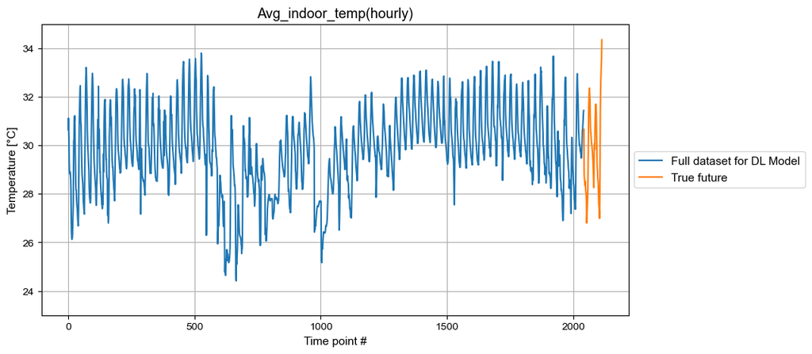

```python
# Avg_indoor_temp(hourly)
#===========================================================================
fig = plt.figure(figsize=(10, 5))

plt.plot(df_initial['Timepoint'],df, label='Full dataset for DL Model')
plt.plot(df_future['Timepoint'],True_Future, label='True future')
plt.title('Avg_indoor_temp(hourly)')
plt.xlabel("Time point #", axis_font)
plt.ylabel("Temperature [°C]", axis_font)
plt.legend(loc='center left', bbox_to_anchor=(1, 0.5))
#plt.xlim([datetime.date(2024, 3, 1), datetime.date(2024,3,10)])
plt.ylim(Indoor_Temp_min-1,Indoor_Temp_max+1)
#plt.xticks(rotation=70)
plt.grid()
#plt.legend()
plt.show()
```

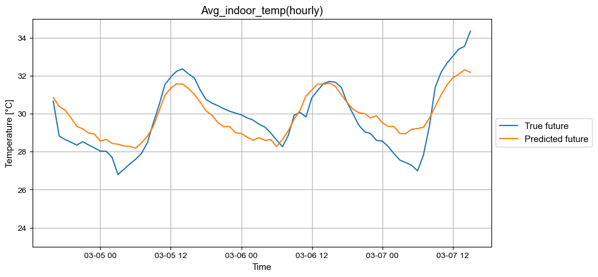

```python
# Avg_indoor_temp(hourly)
#===========================================================================
fig = plt.figure(figsize=(10, 5))

#plt.plot(df_date,df, label='Full dataset for DL Model')
plt.plot(forecast_dates,True_Future, label='True future')
plt.plot(forecast_dates,forecast, label='Predicted future')
plt.title('Avg_indoor_temp(hourly)')
plt.xlabel("Time", axis_font)
plt.ylabel("Temperature [°C]", axis_font)
plt.legend(loc='center left', bbox_to_anchor=(1, 0.5))
#plt.xlim([datetime.date(2024, 2, 25), datetime.date(2024,3,8)])
plt.ylim(Indoor_Temp_min-1,Indoor_Temp_max+1)
#plt.xticks(rotation=70)
plt.grid()
#plt.legend()
plt.show()
```

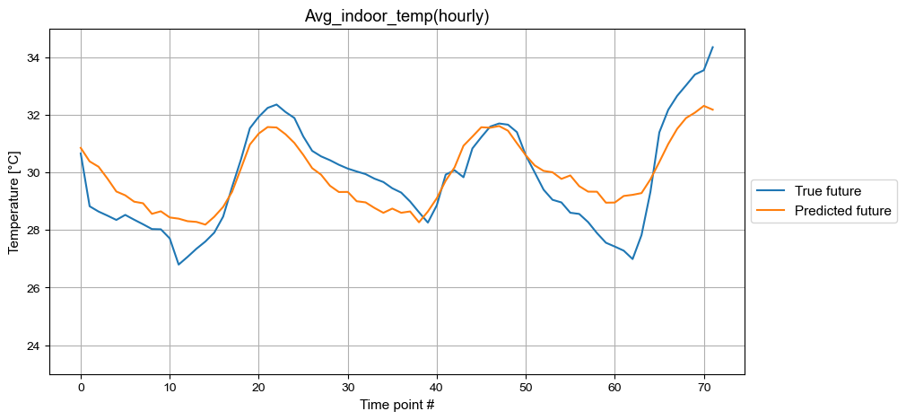

```python
# Avg_indoor_temp(hourly)
#===========================================================================
fig = plt.figure(figsize=(10, 5))
plt.plot(True_Future, label='True future')
plt.plot(forecast, label='Predicted future')

plt.title('Avg_indoor_temp(hourly)')
plt.xlabel("Time point #", axis_font)
plt.ylabel("Temperature [°C]", axis_font)
plt.legend(loc='center left', bbox_to_anchor=(1, 0.5))
plt.ylim(Indoor_Temp_min-1,Indoor_Temp_max+1)
#plt.xticks(rotation=70)
plt.grid()
#plt.legend()
plt.show()
```

## **6. Save the Trained model**

```python
model.save("LSTM_model.h5")
```

```python
# Save the trained DL model for deployment
import pickle

# X_scaler : MiMinMaxScaler to normalize the input data
pickle.dump(X_scaler, open('Scaler_for_Inputdata.pkl','wb'))

# Tair_scaler : MiMinMaxScaler to normalize the predicted temperature
pickle.dump(Tair_scaler, open('Scaler_for_Prediction.pkl','wb'))

pickle.dump(no_prev_timepoints, open('Timepoints_Past.pkl','wb'))
pickle.dump(n_future_tps, open('Timepoints_Future.pkl', 'wb'))
```